# Data Exploration and Visualization of the Bay Wheel Bike Share System

## by Hadi Najar

## Investigation Overview

The goal of this project is to explore and analyze the obtained dataset, find any interesting relationship betweek the columns in the data frame and use proper visualazation to convey my findings.

## Dataset Overview

The dataset I have analyzed is from Bay Wheel for the monthe of November 2019. It contains data like duration of the trip, user types, start and end latitude and longitude, and whether the user uses the bike share for the entire trip or not. I will be looking at a few of these variables and share my findings here.

## Duration distribution of users

Duration is the time a users uses a bike. Based on the histogram, the duration of most users are ~600 seconds or 10 min. Some users have used the bikes for as little as 1 min and some other as long as 86 ksec or 24 hrs.

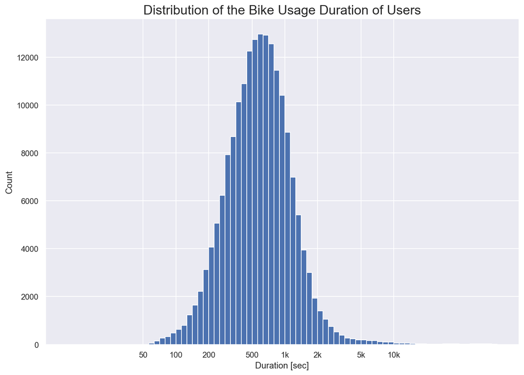

```python
# log-scale histogram shows more data
log_binsize = 0.05
bins = 10 ** np.arange(1, np.log10(df.duration_sec.max())+log_binsize, log_binsize)

plt.figure(figsize=[11.69, 8.27])
plt.hist(data = df, x = 'duration_sec', bins = bins)
plt.xscale('log')
plt.xticks([50, 100, 200, 500, 1e3, 2e3, 5e3, 1e4], [50, 100, 200, 500, '1k', '2k', '5k', '10k'])
plt.xlabel('Duration [sec]')
plt.ylabel('Count')
plt.title('Distribution of the Bike Usage Duration of Users', fontsize = 18);
```

## Proportion of user types

It is interesting that most of the user types (i.e., 77.4%) are Subscribers (Members) and and 22.6% are customers (Casual users).

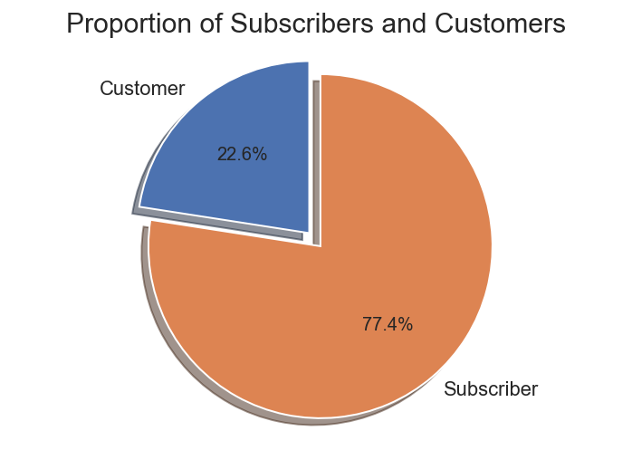

```python
labels = 'Customer', 'Subscriber'
sizes = [df.query('user_type == "Customer"')['user_type'].count(), \
         df.query('user_type == "Subscriber"')['user_type'].count()]
explode = (0, 0.1)  # only "explode" the 2nd slice (i.e. 'Subscriber')

fig1, ax1 = plt.subplots()
ax1.pie(sizes, explode=explode, labels=labels, autopct='%1.1f%%',
        shadow=True, startangle=90)
ax1.axis('equal');  # Equal aspect ratio
plt.title('Proportion of Subscribers and Customers', fontsize = 15);
```

## Proportion of user who use bike share for the entire trip

Surprisingly, it looks like that only 7.5% of the users use the bike share system for their entire trip and the rest of the users use it for part of their trip.

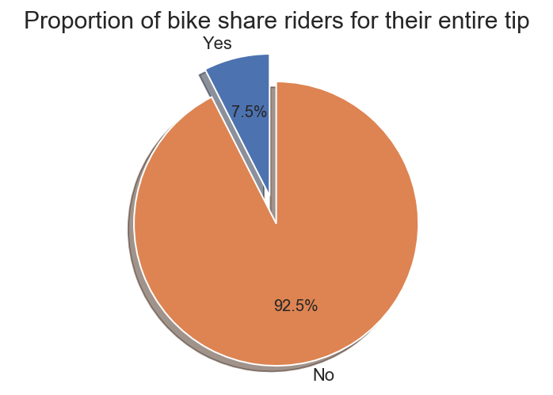

```python
labels = 'Yes', 'No'
sizes = [df.query('bike_share_for_all_trip == "Yes"')['bike_share_for_all_trip'].count(), \
         df.query('bike_share_for_all_trip == "No"')['bike_share_for_all_trip'].count()]
explode = (0, 0.2)

fig1, ax1 = plt.subplots()
ax1.pie(sizes, explode=explode, labels=labels, autopct='%1.1f%%',
        shadow=True, startangle=90)
ax1.axis('equal');  # Equal aspect ratio
plt.title('Proportion of bike share riders for their entire tip', fontsize = 15);
```

## Distance Travelled Distribution

I used the start and end latitude and longitude data to convert to the distance traveled. It is interesteing to put everything in the log scale and conclude that most users traveled an average of 1.5-2 km in this month.

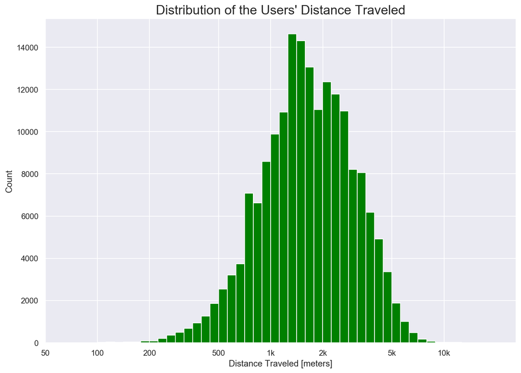

```python
#Earth's means radius in meters
R = 6371e3

#define a function to return the distance between 2 sets of longitude and latitude. Latitude, phi, and longitude, lambda, are in degrees
#The function return the distance in meters

def f(phi1, lambda1, phi2, lambda2):
    Dphi = np.radians(phi2)-np.radians(phi1)
    Dlambda = np.radians(lambda2)-np.radians(lambda1)
    a = np.sin(Dphi/2)**2+np.cos(phi1)*np.cos(phi2)*np.sin(Dlambda/2)**2
    c = 2*np.arctan2(np.sqrt(a),np.sqrt(1-a))
    d = R*c
    return d

df['travel_dist'] = f(df.start_station_latitude,df.start_station_longitude, df.end_station_latitude,df.end_station_longitude)
#make a new DF to eliminate those rows with 0.0!
df2 = df[(df.end_station_latitude != 0.0) & (df.end_station_longitude != 0.0) &(df.start_station_latitude != 0.0) & (df.start_station_longitude != 0.0)]

######################################################################
# log-scale histogram shows better visualization
log_binsize = 0.05
bins = 10 ** np.arange(2, np.log10(df2.travel_dist.max())+log_binsize, log_binsize)

plt.figure(figsize=[11.69, 8.27])
plt.hist(data = df2, x = 'travel_dist', bins = bins, color = 'green')
plt.xscale('log')
plt.xticks([50, 100, 200, 500, 1e3, 2e3, 5e3, 1e4], [50, 100, 200, 500, '1k', '2k', '5k', '10k'])
plt.xlabel('Distance Traveled [meters]')
plt.ylabel('Count');
plt.title('Distribution of the Users\' Distance Traveled', fontsize = 18);
```

## Distance and Duration relationship

the conclusion from the scatterplot, there is just weak correlation between the ditance traveled and duration when put into a log scale. This suggests that, although weak, the speed at which the users travel are somewhat correlated.

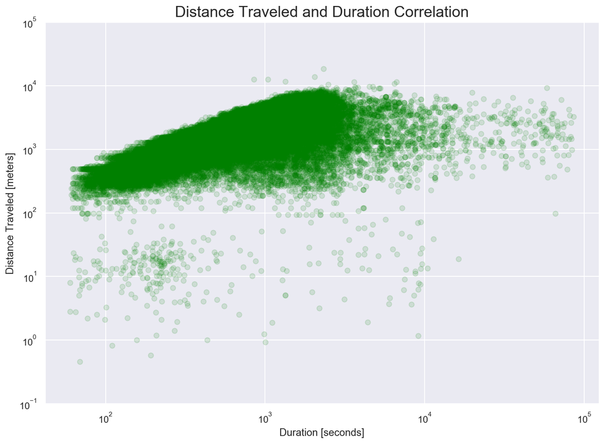

```python
plt.figure(figsize=[11.69, 8.27])
plt.scatter(data = df2, x = 'duration_sec', y = 'travel_dist', alpha = 1/8, color = 'green')
plt.ylim([0.1,10**5])
plt.yscale('log')
plt.xscale('log')
plt.ylabel('Distance Traveled [meters]')
plt.xlabel('Duration [seconds]');
plt.title('Distance Traveled and Duration Correlation', fontsize = 18);
```

## Comparing Distance Traveled for different user types

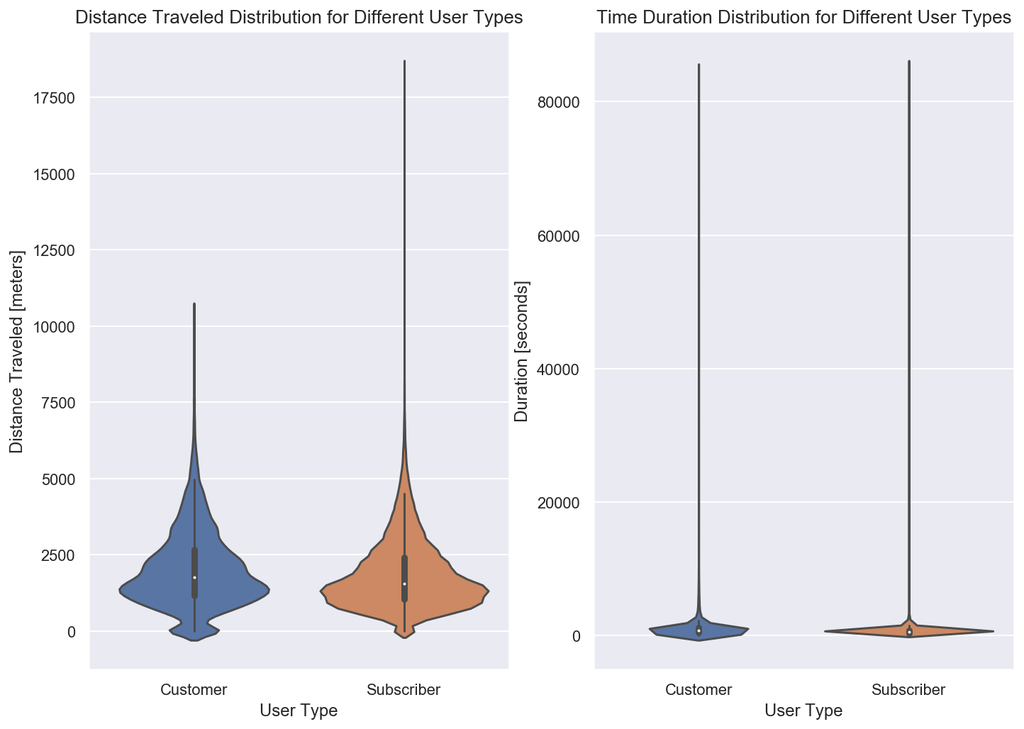

```python
fig, ax = plt.subplots(ncols = 2, nrows = 1 , figsize = [11.69, 8.27])

sns.violinplot(data = df2, x = 'user_type', y = 'travel_dist', ax = ax[0])
sns.violinplot(data = df2, x = 'user_type', y = 'duration_sec', ax = ax[1])
ax[0].set_xlabel('User Type')
ax[0].set_ylabel('Distance Traveled [meters]');
ax[0].set_title('Distance Traveled Distribution for Different User Types', fontsize = 13);

ax[1].set_xlabel('User Type')
ax[1].set_ylabel('Duration [seconds]');
ax[1].set_title('Time Duration Distribution for Different User Types', fontsize = 13);
```

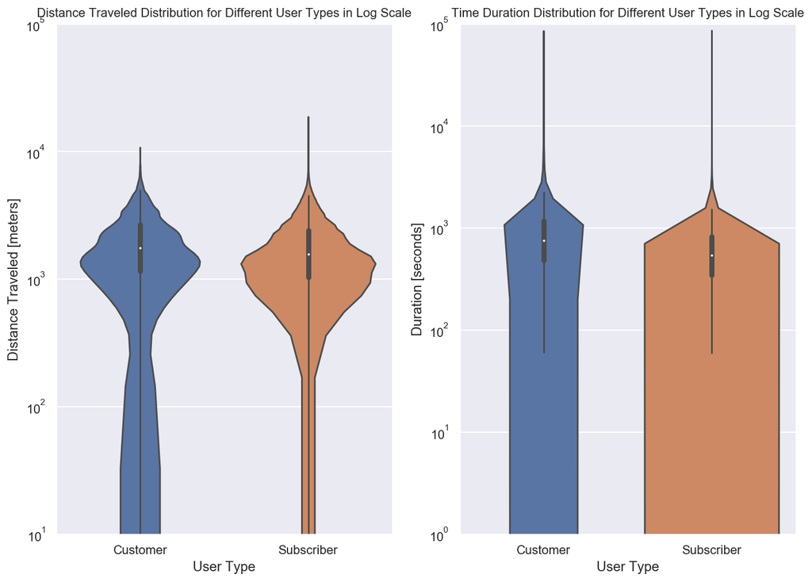

```python
#Let's also look at the log scale version for better visulaization
fig, ax = plt.subplots(ncols = 2, nrows = 1 , figsize = [11.69, 8.27])
sns.violinplot(data = df2, x = 'user_type', y = 'travel_dist', ax = ax[0])
sns.violinplot(data = df2, x = 'user_type', y = 'duration_sec', ax = ax[1])

ax[0].set_yscale('log')
ax[0].set_title('Distance Traveled Distribution for Different User Types in Log Scale', fontsize = 11);
ax[0].set_ylim([10, 10**5])
ax[0].set_xlabel('User Type')
ax[0].set_ylabel('Distance Traveled [meters]');

ax[1].set_yscale('log')
ax[1].set_ylim([1, 10**5])
ax[1].set_xlabel('User Type')
ax[1].set_ylabel('Duration [seconds]')
ax[1].set_title('Time Duration Distribution for Different User Types in Log Scale', fontsize = 11);
```

## Comparing Distance for user who use bike share for all trips and those who don't

- The conclusion from the two plot is that the distance traveled for most of the users who use bike share for all the trip, is around 1km where are it is more spread out for those who do not use bike share for all trip. Furthermore, the median of the distance traveled for the latter case is higher than the former case. Keep in mind that 92.5% of the users do NOT use bike share for all trip.
- The users who do not use bike share for entire trip, on average spend longer time biking that those who do. This may mean that there is a small fraction of users that use bike share to get to their destination because their destination is very close to the starting point or they generally bike faster

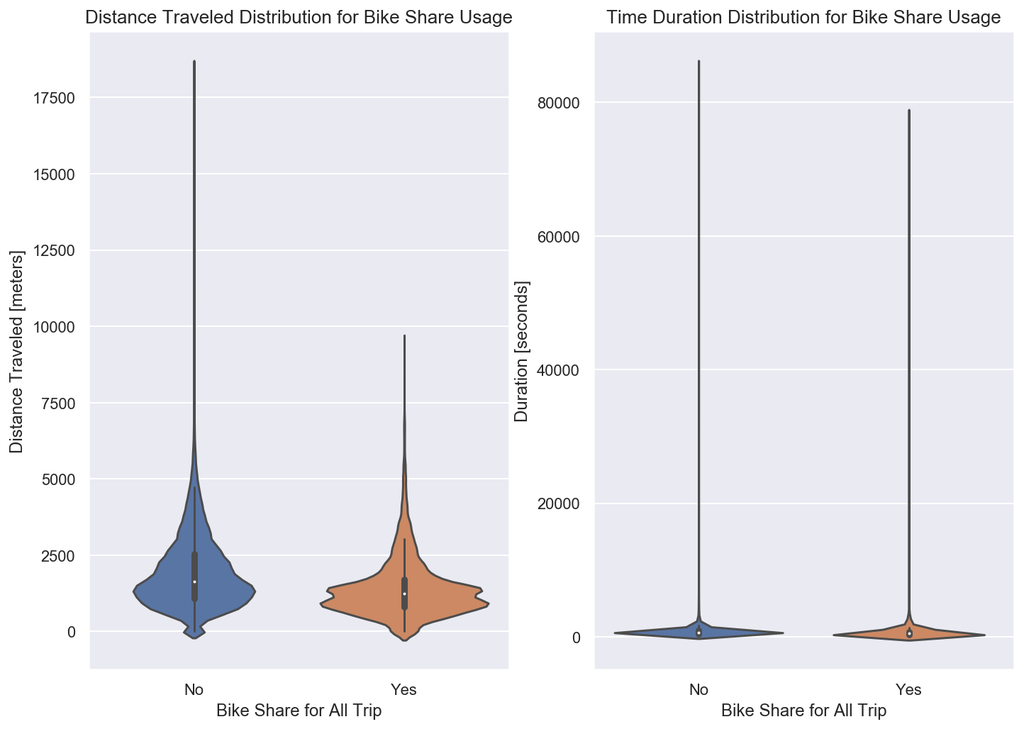

```python
fig, ax = plt.subplots(ncols = 2, nrows = 1 , figsize = [11.69, 8.27])
sns.violinplot(data = df2, x = 'bike_share_for_all_trip', y = 'travel_dist', ax = ax[0])
sns.violinplot(data = df2, x = 'bike_share_for_all_trip', y = 'duration_sec', ax = ax[1])

ax[0].set_xlabel('Bike Share for All Trip')
ax[0].set_ylabel('Distance Traveled [meters]');
ax[0].set_title('Distance Traveled Distribution for Bike Share Usage', fontsize = 13);

ax[1].set_xlabel('Bike Share for All Trip')
ax[1].set_ylabel('Duration [seconds]');
ax[1].set_title('Time Duration Distribution for Bike Share Usage', fontsize = 13);
```

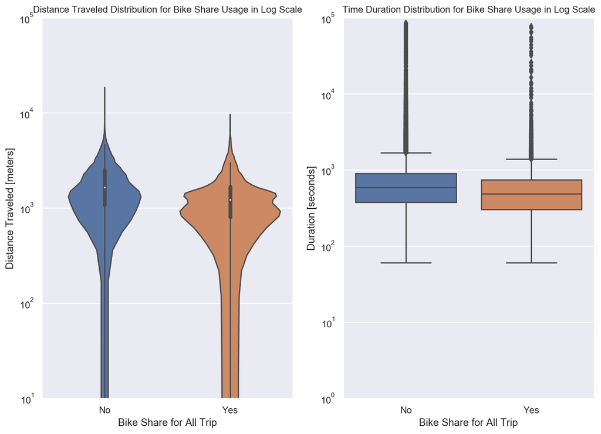

```python
#Let's also look at the log scale version for better visulaization
fig, ax = plt.subplots(ncols = 2, nrows = 1 , figsize = [11.69, 8.27])
sns.violinplot(data = df2, x = 'bike_share_for_all_trip', y = 'travel_dist', ax = ax[0])
sns.boxplot(data = df2, x = 'bike_share_for_all_trip', y = 'duration_sec', ax = ax[1])

ax[0].set_yscale('log')
ax[0].set_ylim([10, 10**5])
ax[0].set_xlabel('Bike Share for All Trip')
ax[0].set_ylabel('Distance Traveled [meters]');
ax[0].set_title('Distance Traveled Distribution for Bike Share Usage in Log Scale', fontsize = 11);

ax[1].set_yscale('log')
ax[1].set_ylim([1, 10**5])
ax[1].set_xlabel('Bike Share for All Trip')
ax[1].set_ylabel('Duration [seconds]');
ax[1].set_title('Time Duration Distribution for Bike Share Usage in Log Scale', fontsize = 11);
```

## Analyzing in Multivariate Domain

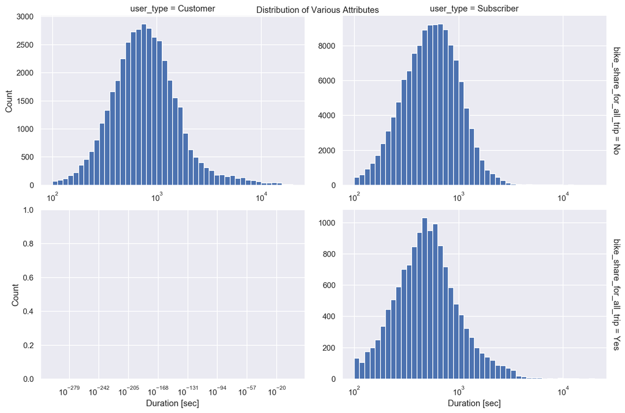

```python
g = sns.FacetGrid(data = df2, col = 'user_type', row = 'bike_share_for_all_trip', height=4, aspect=1.5,sharex=False,sharey=False, margin_titles = True)
log_binsize = 0.05
bins = 10 ** np.arange(2, np.log10(df2.travel_dist.max())+log_binsize, log_binsize)
g.map(plt.hist, 'duration_sec', bins = bins).set(xscale = 'log')
g.set_ylabels('Count').set_xlabels('Duration [sec]')
g.fig.suptitle('Distribution of Various Attributes');
```

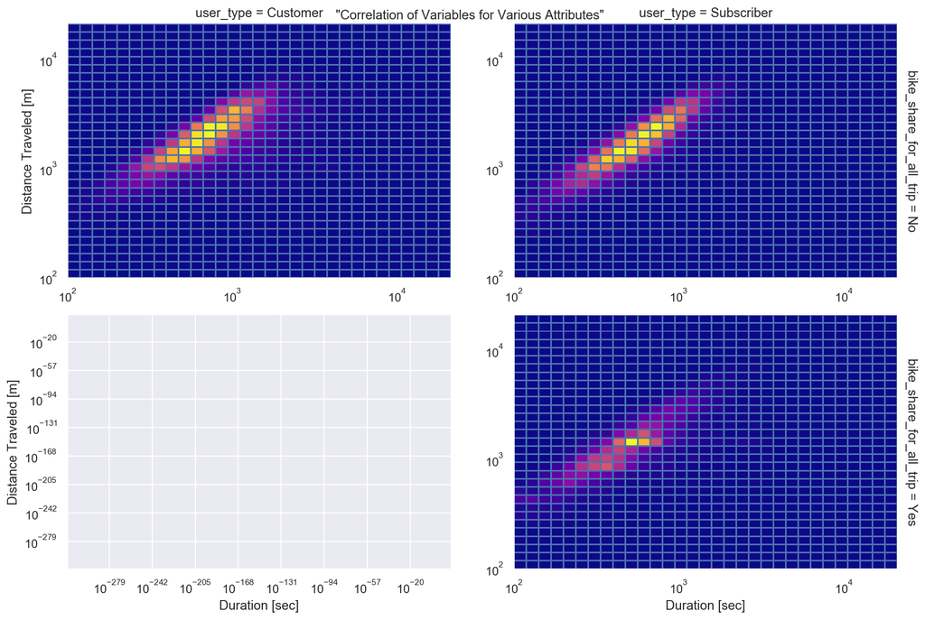

```python
sns.axes_style({'axes.grid': False})
g = sns.FacetGrid(data = df2, col = 'user_type', row = 'bike_share_for_all_trip', height=4, aspect=1.5, sharex=False,sharey=False, margin_titles = True)

log_binsize = 0.075
bins = 10 ** np.arange(2, np.log10(df2.travel_dist.max())+log_binsize, log_binsize)
g.map(plt.hist2d, 'duration_sec', 'travel_dist', bins = bins, cmap = 'plasma').set(xscale = 'log').set(yscale = 'log')
g.set_xlabels('Duration [sec]').set_ylabels('Distance Traveled [m]')
g.fig.suptitle('    \"Correlation of Variables for Various Attributes\"');
```